# intro to Bayesian analysis

A. Scientificus

2018-08-24

*disclaimer: this is very unlikely to be useful to anyone other than myself. if you want to real-deal, go to [data camp](https://www.datacamp.com/) and check out: [fundamentals of bayesian data analysis in r](https://www.datacamp.com/courses/fundamentals-of-bayesian-data-analysis-in-r)* which I thought was very good.

## preliminaries

```r
library(tidyverse)
```

also, intentionally did not `set.seed()` because I actually want it to vary over refreshes, the essential patterns should stay the same

## essential recipe

generative model + priors + data = bayesian inference

## magical armour examples

there is the assertion that there is a magical armour in a video game that will will completely nullify an opponent’s attack 15% of the time:  
* parameters - size = 100 attacks - prob = 0.15 * generative model - `rbinom`

we have reason to wonder if 15% is an unfailing accurate estimate of attacks nullified. for priors, we will reasonably guess it is potentially anything between a complete dud (i.e. it’s a normal armour and it never completely nullifies an attack) or it is x2 better, and it nullifies attacks 30% of the time.

```r
n_iterations <- 10^4
n_attacks <- 100
prop_nullified <- runif(n = n_iterations, min = 0.0, max = 0.3)
n_nullified <- rbinom(n = n_iterations, size = n_attacks, prob = prop_nullified)

my_col <- "cornflowerblue"
```

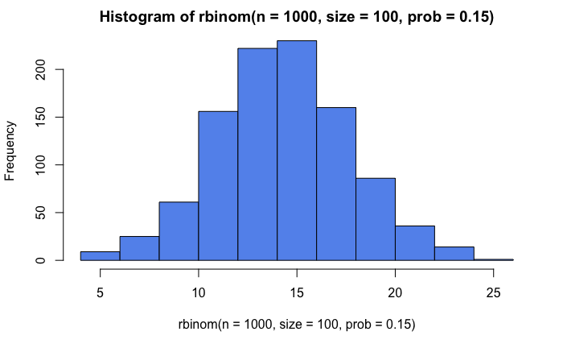

```r
hist(rbinom(n = 1000, size = 100, prob = .15), col = my_col)
```

which is same as as doing this 1000 times:

```r
1:100 %>%
  map_lgl(~runif(n = 1, min = 0, max = 1) < .15) %>%
  sum() / 100
```

```
[1] 0.15
```

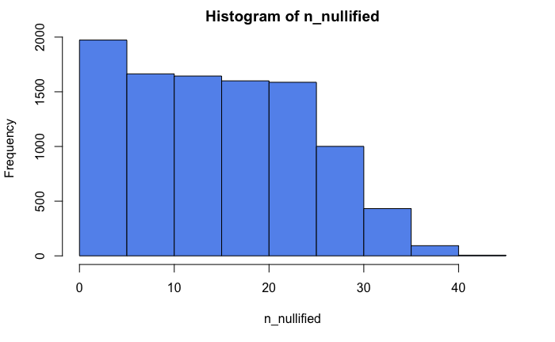

```r
hist(n_nullified, col = my_col)
```

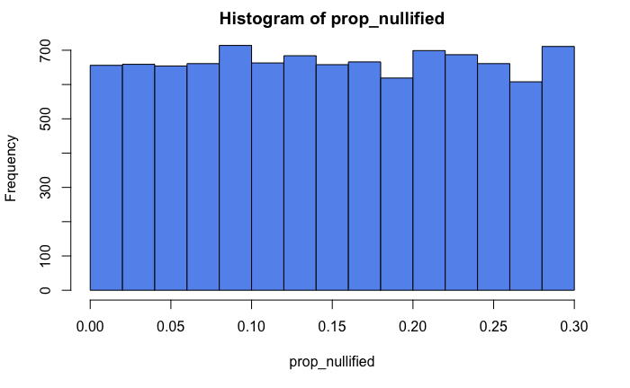

```r
hist(prop_nullified, col = my_col)
```

# “conditioning” using real data

so, walking through the woods was actually attacked, and conviently from the point of view of this analysis, there 100 rounds of combat and the armour completely nullified 11 of those attacks:

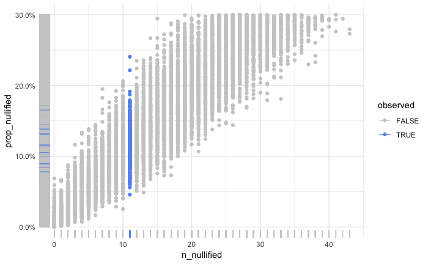

```r
prior_0 <- tibble(prop_nullified, n_nullified) %>%
  mutate(observed = n_nullified == 11)

prior_0 %>%
  ggplot(aes(x = n_nullified,
             y = prop_nullified,
             colour = observed)) +
  geom_point() +
  geom_rug() +
  scale_colour_manual(values = c("grey80", my_col)) +
  scale_y_continuous(labels = scales::percent) +
  theme_minimal()
```

the data we got from the attack in the woods allows us to *condition* or refine our estimate of the likelihood of nullifing an attack from the uniform distribution that ranged from 0-30% to something like this:

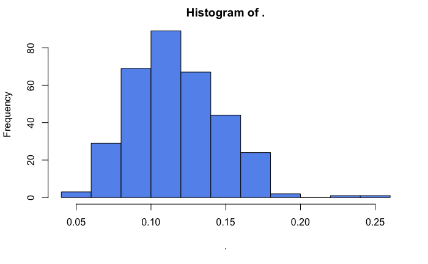

```r
posterior <- prior_0 %>% filter(observed == TRUE)

posterior %>%
  select(prop_nullified) %>%
  as_vector() %>%
  hist(x = ., col = my_col)
```

This is the fundamental Bayesian notion: *use observed values to infer model parameters by contrasting what you actually observed with your prior estimate of those parameters.*

with our knowledge of that 11 attacks were nullified, if we combined that with the previous understanding of the likely range of nullification rates, what would be reasonable range of attacks that would be nullified next time we are attacked?

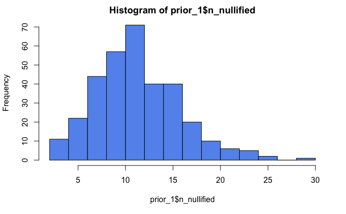

```r
prior_1 <- posterior

prior_1$n_nullified <- rbinom(n = nrow(prior_1), size = 100, prob = posterior$prop_nullified)

hist(prior_1$n_nullified, col = my_col )
```

So, what is the likelihood of having:

- $>=5$ nullified? 0.9665653, so unlikely a complete dude
- $>=15$ nullified? 0.2553191, not likely as good as advertised
- $>=30$ nullified? 0.0030395, almost certainly not extra good